# Statystyka 2, projekt pierwszy faza trzecia

Michal Kotlewski, Szymon Majewski

# Wstepne przygotowanie danych

Dane ładujemy, usuwamy z nich niepotrzebne kolumny, oraz kolumny dla których co najmniej 10 przykładów ze zbioru treningowego nie ma wartości. Następnie zastępujemy wartości NA w zbiorze treningowym i testowym średnimi ze zbioru treningowego, oraz standaryzujemy dane.

```r
  #Ładujemy dane
  load("~/STAT2/2016/proj1/GlioblastomaWide.rda")
  d <- GlioblastomaWide
  rm(GlioblastomaWide)
  test_d = read.csv("~/STAT2/2016/final.csv")

  #Usuwamy niepotrzebne kolumny
  d$sampleID <- NULL
  d$Cluster <- NULL
  test_d$Cluster <- NULL

  #Zachowujemy potrzebne kolumny w oddzielnych zmiennych
  death1y <- d$death1y
  d$death1y <- NULL
  rowid <- test_d$rowid
  test_d$rowid <- NULL

  #Usuwamy kolumny ze zbyt dużą liczbą NA
  ncd = ncol(d)

  for (i in 1:ncd) {
    #Jeśli w zbiorze treningowym w kolumnie jest co najmniej 10 NA ...
    if(sum(is.na(d[,ncd+1-i]))>= 10) {
      # ... usuń kolumnę ze zbioru treningowego i testowego
      d[,ncd+1-i] <- NULL
      test_d[,ncd+1-i] <- NULL
    }
  }

  # Uzupełniamy resztę NA
  for(i in 1:(ncol(d))){
    # W zbiorze treningowym zastępujemy NA średnią z kolumny
    d[is.na(d[,i]), i] <- mean(d[,i], na.rm = TRUE)
    # W zbiorze testowym zastępujemy NA średnią z analogicznej kolumny w zbiorze treningowym
    test_d[is.na(test_d[,i]),i] <- mean(d[,i], na.rm= TRUE)
  }

  # Standaryzujemy dane
  for(i in 1:(ncol(d))){
    mdi <- mean(d[,i]);
    sdi <- sd(d[,i]);
    # Od danych tren. i test. odejmujemy średnią kolumn z danych treningowych,
    # i dzielimy przez odchylenie standardowe kolumn danych treningowych
    d[, i] <- (d[,i] - mdi)/sdi
    test_d[,i] <- (test_d[,i] - mdi)/sdi
  }
```

# Wybór zmiennych

```r
  set.seed(285)
  cvfit_08 <- cv.glmnet(x=X, y=(death1y == "alive"), alpha=0.8, family="binomial")
```

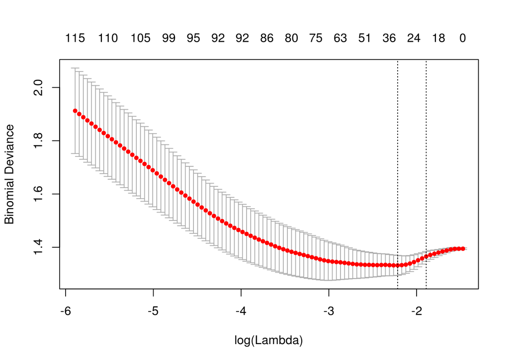

```r
plot(cvfit_08)
```

```r
  Coefficients <- coef(cvfit_08, s=cvfit_08$lambda.min)
  Active.Index <- which(Coefficients != 0)

  # Obcinamy zbiory treningowy i testowy do jedynie tych wybranych kolumn
  d_cut <- X[, Active.Index]
  test_d_cut <- test_d_mat[,Active.Index]
  d_cut_df <- as.data.frame.matrix(d_cut)
  d_cut_df$death1y <- as.factor(death1y)
  test_d_cut_df <- as.data.frame.matrix(test_d_cut)
```

# Cross walidacje

Do wyboru hiperparametrów różnych modeli, oraz wyboru modeli stosujemy cross walidację 10-fold, powtórzoną 10 krotnie. Wykorzystujemy w tym celu pakiet caret. Przykładowo, dla gradient boostingu z pakietu gbm wykonujemy:

```r
  fitControl <- trainControl(
        # Używamy cross walidacji
        method = "repeatedcv",
        # 10 foldów
        number = 10,
        # 10 razy powtarzamy
        repeats = 10)

  # Przykładowa siatka parametrów
  gbmGrid <-  expand.grid(interaction.depth = c(1,2,3,4),
                          n.trees = (25:75)*2,
                          shrinkage = c(0.1,0.2),
                          n.minobsinnode = c(2,9))

  # Używamy pakietu caret do automatycznego przeprowadzenia cross validacji
  gbmFit <- train(death1y ~ ., data = d_cut_df,
                  method = "gbm",
                  trControl = fitControl,
                  verbose = FALSE,
                  tuneGrid = gbmGrid)
```

Następnie tworzymy wykres przedstawiający otrzymane wyniki cross walidacji dla różnych hiperparametrów:

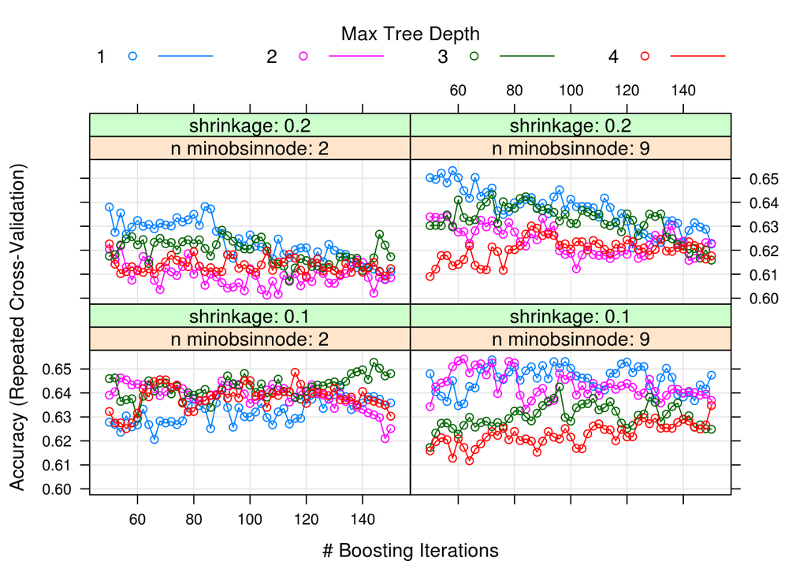

```r
plot(gbmFit)
```

Na podstawie powyższego wykresu wybieramy najlepsze zestawy parametrów. Podobną procedurę stosujemy dla różnych innych modeli, w tym Random Forest, SVM, Naive Bayes, sieci neuronowe (pakiet nnet), glmnet.

# Budowanie modeli

Dla wybranych zestawów parametrów budujemy modele. Predykcje dla jednego konkretnego typu modeli otrzymujemy uśredniając predykcje dla różnych zestawów hiperparametrów. Przykładowo dla modelu gbm:

```r
  #Budujemy modele na podstawie parametrów wybranych w cross walidacji
  gbm1 <- gbm(death1y == "alive" ~ . , data=d_cut_df,
      distribution="bernoulli",
      interaction.depth = 1,
      n.minobsinnode=9,
      shrinkage=0.2,
      n.trees=60)
  gbm2 <- gbm(death1y == "alive" ~., data=d_cut_df,
              distribution="bernoulli",
              interaction.depth=3,
              n.minobsinnode = 2,
              shrinkage=0.1,
              n.trees = 145)
  gbm3 <- gbm(death1y == "alive" ~., data=d_cut_df,
              distribution="bernoulli",
              interaction.depth=1,
              n.minobsinnode = 9,
              shrinkage=0.1,
              n.trees = 90)

  # Uśredniamy predykcje powyższych trzech modeli
  gb_pred <- (predict(gbm3, test_d_cut_df, n.trees=90) +
                predict(gbm2, test_d_cut_df, n.trees=145) +
                predict(gbm1, test_d_cut_df, n.trees=60))
```

Jeśli dla danego typu modelu wybraliśmy jeden zestaw parametrów, to budujemy jedynie model i wykonujemy predykcje dla tego modelu.

# Uśrednianie modeli

Uśredniamy wybrane modele, poprzez głosowanie większościowe. Każdy model głosuje czy dany pacjent przeżyje rok czy nie. Następnie podejmujemy decyzję na podstawie tego która możliwość otrzymała więcej głosów.

```r
svm_rf_gbm <- (svm.pred_test == "alive") + (pred_rf_test == "alive") + (gb_pred > 0)
Expected <- as.numeric(svm_rf_gbm < 2)
```

Które modele warto uśredniać? Oczywiście do uśredniania wybieraliśmy modele które w cross walidacji dawały dobre wyniki. Poza tym staraliśmy się łączyć te modele, które myliły się na różnych podzbiorach zbioru treningowego, oraz pomimo porównywalnych wyników w cross walidacji dawały inne predykcje na zbiorze testowym. W ten sposób łączone modele były “różne”, więc ich średnia miała szanse być lepsza niz każdy osobno.

# Model Stacking

Poza tym próbowaliśmy wykonywać model stacking, na podstawie naszego rozumienia opisu tej techniki zaprezentowanego na kaggle: http://mlwave.com/kaggle-ensembling-guide/ . Niestety ta metoda nie dała zbyt dobrych wyników w teście na części danych na platformie Kaggle, więc ją porzuciliśmy.

```
  # Dzielimy zbiór treningowy na dwie części
  train_a_mat <- d_cut[1:62,]
  train_b_mat <- d_cut[63:125,]
  train_a_df <- d_cut_df[1:62,]
  train_b_df <- d_cut_df[63:125,]
  death_a <- death1y[1:62]
  death_b <- death1y[63:125]

  # Trenujemy model glmnet na części A i B
  glm_a <- cv.glmnet(x = train_a_mat, y=death_a, alpha=0, family="binomial" )
  glm_b <- cv.glmnet(x = train_b_mat, y=death_b, alpha=0, family="binomial" )

  # Wykonujemy predykcje dla A i B na podstawie modeli dla B i A
  glm_a_pred <- predict(glm_b, newx = train_a_mat, s="lambda.min", type="response")
  glm_b_pred <- predict(glm_a, newx = train_b_mat, s="lambda.min", type="response")

  # Otrzymujemy wektor nowych cech, będących predykcjami
  glm_f <-rbind(glm_a_pred, glm_b_pred)

  # Podobną procedurę stosujemy dla SVM i Random Forest
  svm.model_a <- svm(death1y ~. , data= train_a_df, type="C-classification", probability=TRUE)
  svm.model_b <- svm(death1y ~. , data= train_b_df, type="C-classification", probability=TRUE)

  svm_a_pred <- predict(svm.model_b, train_a_df, probability=TRUE)
  svm_b_pred <- predict(svm.model_a, train_b_df, probability=TRUE)

  svm_f <- c(attr(svm_a_pred, "probabilities")[,"alive"] , attr(svm_b_pred, "probabilities")[,"alive"])

  rf_a <- randomForest(death1y~ . , data=train_a_df)
  rf_b <- randomForest(death1y~ . , data=train_b_df)

  pred_rf_a <- predict(rf_b, train_a_df, type="prob")
  pred_rf_b <- predict(rf_a, train_b_df, type="prob")

  rf_f <- c(pred_rf_a[,"alive"], pred_rf_b[,"alive"])

  # Otrzymujemy nowe dane.
  new_data <- data.frame(death1y, glm_f, svm_f, rf_f)

  # Obliczamy nowe cechy dla zbioru testowego na podstawie predykcji z wybranych modeli
  glm_test <- cv.glmnet(x = d_cut, y=death1y, alpha=0, family="binomial" )
  glm_test_f <- predict(glm_test, newx = test_d_cut, s="lambda.min", type="response")

  svm.model_test <- svm(death1y ~. , data= d_cut_df, type="C-classification", probability=TRUE)
  svm_test_pred <- predict(svm.model_test, test_d_cut_df, probability=TRUE)
  svm_test_f <- attr(svm_test_pred, "probabilities")[,"alive"]

  rf_test <- randomForest(death1y~ . , data=d_cut_df)
  pred_rf_test <- predict(rf_test, test_d_cut_df, type="prob")
  rf_test_f <- pred_rf_test[,"alive"]

  # Tworzymy nowe dane testowe
  new_test <- data.frame(glm_test_f, svm_test_f, rf_test_f)
  colnames(new_test) <- colnames(new_data)[-1]

  # Uczymy model liniowy i wykonujemy predykcje
  big_lm <- glm(death1y~. , data=new_data, family="binomial")
  ex_ms <- (predict(big_lm, new_test, type="link") <= 0)
```